# FINAL PROJECT

Bilgen Yılmaz

1/10/2021

# PART 1

## Question 1

Timnut Gebru had been fired by Google because she co-wrote a paper which discusses the potential downsides of the large language models. She was co-head of Google’s ethical AI team and was working on a paper with 5 other collaborators and to my understanding she mailed Google’s Head of AI Jeff Dean about paper they were working on and ask for feedbacks& comments. After that she claimed she was fired immediately.

I want to discuss this controversy in two aspects, first freedom of researches and second AI ethics. In terms of freedom of research, I strongly disagree with the firing decision after a worker had made a research that may have include findings against company’s interest. There are so many ways other than this such as taking into a consideration of the critics and finding a solution to improve your workflows according to it. But I do not believe in this system any company who has an image or profit concerns will do the right thing when they feel threatened.

In terms of AI Ethics, main points made by paper was energy efficiency of language models, unbiased and manageable data and manipulation of meaning. I think environmental concerns for big models shown in article is critical and can really make a positive effect in consumption since their usage will probably increase in future.

For unbiased and manageable data, paper claimed that since data of language collected from internet without filtering it can include sexist and racist words. Though I believe these are wrong and can affect results, otherwise would be a manipulation of inputs by human hand. And for my opinion manipulation by human hand is as dangerous as this. Because if someone will define ‘normal’ or ‘ethical’ for language inputs – a company, government etc. – it also made me think why this acceptance are true and normal? Isn’t there a chance this definition of ‘normal’ work for a favor of their creators? For example, let’s say we have 100 people searching on Google; 20 of them are criminals, 40 of them white collars, 30 of blue collars, 10 of them unemployed. Why should algorithms take a consider of people types and excludes criminals from their inputs? For equality I believe raw data will do a better job than manipulated – human work included- data. Still there is a problem stated in paper with ignoring some languages whom have a searching volume but doesn’t take into an account because they are spoken in poor countries should be considered by models maybe localized models would do better jobs.

For abusing results to impact users of Google is a serious concern and I am pretty sure data outcomes, or any information are used for guide population opinion by government and companies. But even before AI and Google, manipulation of population was being done, besides online still offline marketing is being done. The main problem here is that Google, internet and AI regulations are new and insufficient (since the topics new), I believe heavy regulations are yet to come and after regulations these manipulations can be done in more acceptable ways.

## Question 2

Approximately %35-%65 (gut feeling& experience to data&forecast) would be optimum, I guess. In order to do effective technical analysis and data you should now domain very well. Otherwise a decision solely based on data and forecast can lead you to wrong direction also. But gut feeling and experience percentage shouldn’t be high because with that objectivity are lost and you can be blinded by your opinions.

## Question 3

If I would want to show nottem in one plot I wanted to show the temperature by month. And for each year I would like to show different color in same graph. But I couldn’t reach my initial intent with coding. And closest thin is as follows. We can see average line with geom_smooth and we can see the temperatures for each year with geom_point.

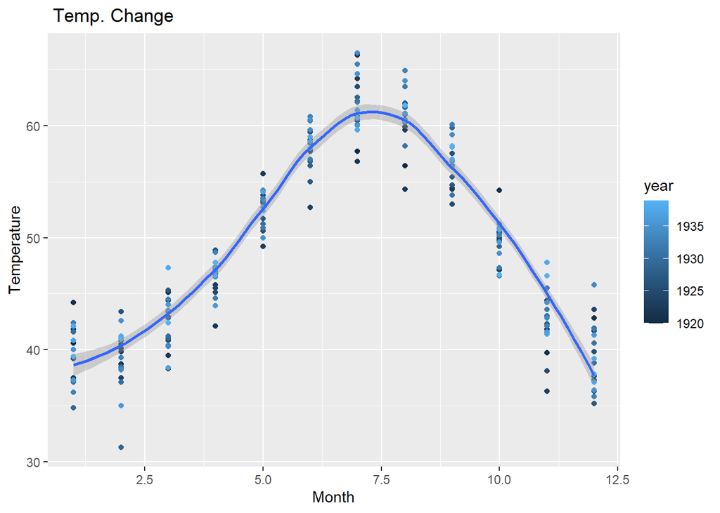

```r
nottem_adj <- data.frame(
yaermonth = as.Date(as.yearmon(time(nottem))), Temprature = melt(nottem))
nottem_adj$value <- as.double(nottem_adj$value)
Yearly_nottem <- nottem_adj %>% group_by(year = lubridate::year(yaermonth))
ggplot(Yearly_nottem, aes(x=lubridate::month(yaermonth), y=value, color=year))+ geom_point()+ geom_smooth() +
labs(title =" Temp. Change", x = "Month", y = "Temperature")
```

# PART 2

## New Analysis for Group Project

In our group project, we examine ISPARK data. From these data we have occupancy of park through 14 days and we have their average monthly prices for monthly subscriptions.

- First I checked for minimum and maximum occupancy rates of each parks during 14 days.
- Second I assume a parks’ minimum occupancy for 11 days can give me its monthly subscribed cars, so I calculated monthly revenue for parks.

In below table you can see the most profitable parks during 18 November - 29 November 2020. And their predicted monthly revenues according to minimum occupancy rate during 18 Nov - 29 Nov.

```r
mergedtable <- merge(x = parkcapacity, y = parkinfo, by = "ParkID", all.x = TRUE)

park_geliri_aylik <-
  mergedtable %>% filter(ParkTipi != "TAKSİ PARK") %>%
  select(Ilce, ParkTipi,ParkID, ParkAdi.x, DolulukYuzdesi, AylikAbonelikÜcreti, Kapasitesi) %>%
  group_by(Ilce,ParkID, ParkAdi.x,ParkTipi, AylikAbonelikÜcreti, Kapasitesi)%>%
  summarise(min_doluluk= min(DolulukYuzdesi), max_doluluk=max(DolulukYuzdesi))

aylik_abone_geliri <- park_geliri_aylik %>% summarise(gelir_abone = AylikAbonelikÜcreti*min_doluluk* Kapasitesi) %>% arrange(desc(gelir_abone))

aylik_abone_geliri %>% head(20)
```

```
## # A tibble: 20 x 6
## # Groups:   Ilce, ParkID, ParkAdi.x, ParkTipi [20]
##    Ilce    ParkID ParkAdi.x              ParkTipi   AylikAbonelikÜc~ gelir_abone
##    <chr>    <int> <chr>                  <chr>                 <dbl>       <dbl>
##  1 EYÜP      1912 Alibeyköy Cep Otogari~ AÇIK OTOP~              250  124600000
##  2 KAGITH~   1303 Seyrantepe Katli (Are~ KAPALI OT~              140   31304000
##  3 EYÜP      1913 Alibeyköy Cep Otogari~ AÇIK OTOP~               60   29466000
##  4 BAKIRK~   1465 Bakirköy Ido Açik Oto~ AÇIK OTOP~              330   28644000
##  5 SISLI     1857 Maçka Katli Otoparki   KAPALI OT~              480   24336000
##  6 BEYOGLU   1181 Karaköy Katli          KAPALI OT~              400   23960000.
##  7 FATIH     1989 Yenikapi Spor ve Kült~ AÇIK OTOP~              200   19680000
##  8 GÜNGÖR~   1472 Merter Katli Otoparki  KAPALI OT~              220   15202000.
##  9 ZEYTIN~   1471 Mevlana Yeralti Katli~ KAPALI OT~              210   14133000.
## 10 BEYOGLU   1155 Cihangir Katli Otopar~ KAPALI OT~              400   14000000
## 11 ATASEH~   1189 Içerenköy Açik Otopar~ AÇIK OTOP~              210   12579000
## 12 SISLI     2406 Sisli Zemin Alti Otop~ KAPALI OT~              300   11010000.
## 13 KADIKÖY   1464 Kadiköy Açik Otoparki  AÇIK OTOP~              290   10846000.
## 14 FATIH     2160 Yenikapi Marmaray Büy~ AÇIK OTOP~              300   10350000.
## 15 BAKIRK~   1186 Bakirköy Ido Iskele Ö~ AÇIK OTOP~              330    9900000
## 16 ARNAVU~   2802 Arnavutköy Zemin Alti~ KAPALI OT~              170    9367000
## 17 SARIYER   1523 Haciosman Metro Yer A~ KAPALI OT~              240    9240000
## 18 ZEYTIN~   1469 Sehit Volkan Duysak K~ KAPALI OT~              200    9160000
## 19 ZEYTIN~   1901 Kazliçesme Marmaray A~ AÇIK OTOP~              130    9100000
## 20 BEYOGLU   2042 Beyoglu Tepebasi Katl~ KAPALI OT~              400    8640000
```

I created two plots for Park Types and Districts by their predicted monthly revenue in November 2020.

It is interesting that Eyüp has the highest revenue among districts because in our park count table, Eyüp was 16th district to have most parks. And besides Eyüp park count and revenue table seems parallel. We may say that even though Eyüp’s parks are less than Bakırköy, Fatih, Şişli, Beyoğlu, due to its capacity and occupancy rate it has higher monthly revenue in November 2020.

Park type’s revenue seem to have a positive correlation by their total capacity. (You can check our group’s final report to see park type’s total capacities)

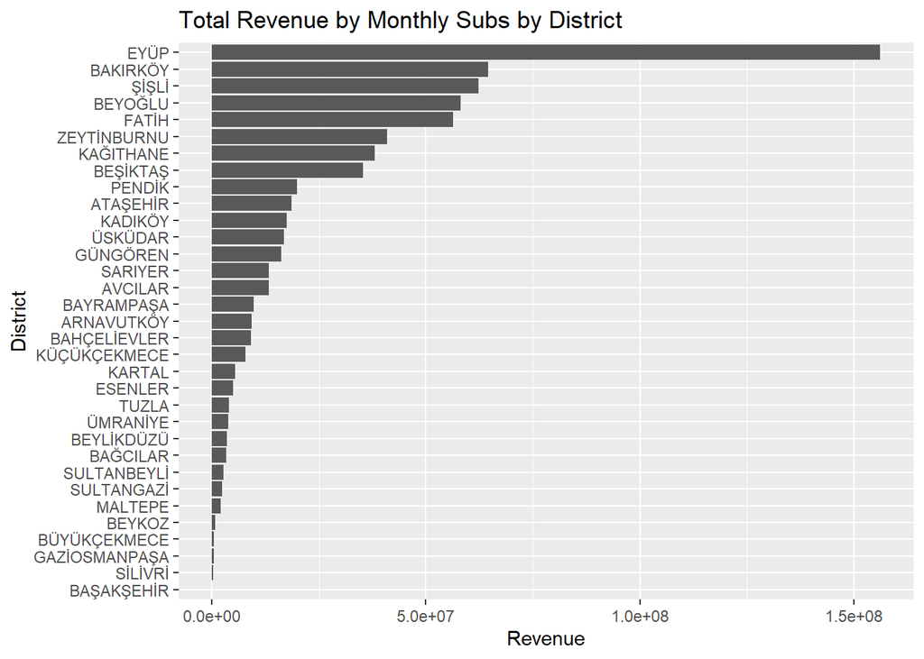

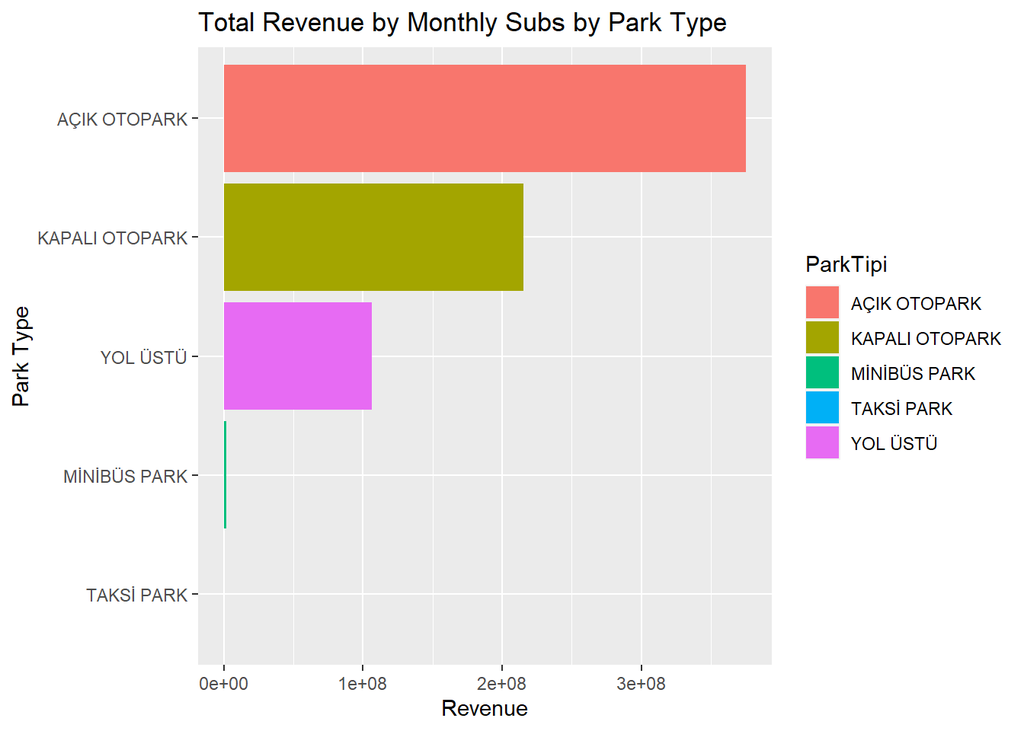

```r
aylik_abone_geliri %>% select(Ilce, gelir_abone) %>% group_by(Ilce) %>% summarise(tot_gelir=sum(gelir_abone)) %>%
  ggplot(aes(x=reorder(Ilce, tot_gelir), y=tot_gelir))+
  geom_bar(position = "stack", stat = "identity")+
  coord_flip()+
  labs(title ="Total Revenue by Monthly Subs by District", x = "District", y = "Revenue")

aylik_abone_geliri %>% select(ParkTipi, gelir_abone) %>% group_by(ParkTipi) %>% summarise(tot_gelir=sum(gelir_abone))%>%
  ggplot(aes(x=reorder(ParkTipi, tot_gelir), y=tot_gelir, fill=ParkTipi))+
  geom_bar(position = "stack", stat = "identity")+
  coord_flip()+
  labs(title ="Total Revenue by Monthly Subs by Park Type", x = "Park Type", y = "Revenue")
```

# PART 3

## Question 1

For RData file click [here.](https://drive.google.com/drive/folders/1HljTPD587jahwFPXw-m60ZRwradrNYKy?usp=sharing)

You will find 3 tables in this RData file;

- `summary_price_merged`: Target Revisions and Summary tables bonded and merged – common columns excluded
- `all_merged`: Estimate Revisions, Target Revisions and Summary tables bonded and merged
- `prediction_table`: Estimate Revisions tables merged

## Question 2

Dataset I will be using includes both `Target Price Revisions` and `Summary` tables. *We have 2 NA’s in data so in later tables we will exclude them from further calculation.*

```r
colnames(summary_price_merged)
```

```
##  [1] "Kod"                "Suggestion"         "Target_Price"
##  [4] "Rev_Potential"      "Sugg_Date"          "Closing"
##  [7] "Market_Price_mn"    "Sector"             "Suggestion_3"
## [10] "Target_Price_3"     "Target_Price_Val_3" "Suggestion_4"
## [13] "Target_Price_4"     "Target_Price_Val_4"
```

### Potentials by Sector

First, I wanted to look if I had money which sectors would be more logical to invest according to data. In first table it seemed that Industry sector has the least total potential for investing. Although when I look by company code, 8 out of top 10 potential is belong to Industry sector. And also 10 out of 10 least potential companies are in Industry sector.

To sum up, investing on banks seems more rewarding however investing on Industry can be risky but rewards could be higher than other sectors either.

```r
summary_price_merged %>% select(Target_Price_4, Rev_Potential,Closing, Market_Price_mn, Sector) %>%
  mutate(potential = Rev_Potential*Target_Price_4/100, Target_Price_4, Rev_Potential) %>%
  group_by(Sector) %>%
  summarise(count= n(), tot_potential=sum(potential, na.rm=T), avg_targetprice=mean(Target_Price_4, na.rm=T),
            avg_potential=mean(Rev_Potential, na.rm=T), avg_closing=mean(Closing))
```

```
## # A tibble: 5 x 6
##   Sector    count tot_potential avg_targetprice avg_potential avg_closing
##   <chr>     <int>         <dbl>           <dbl>         <dbl>       <dbl>
## 1 Bank          8        12.7              5.41        27.3          5.44
## 2 GYO           3        -0.171            2.67        -3.67         3.06
## 3 Holding       4         6.66            16.1          5.5         17.7
## 4 Industry     39       -42.4             37.9          0.289       49.4
## 5 Insurance     3         1.95             8.96         7.33         9.18
```

```r
summary_price_merged %>% select(Target_Price_4, Rev_Potential,Closing, Market_Price_mn, Sector, Kod) %>%
  mutate(potential = Rev_Potential*Target_Price_4/100, Target_Price_4, Rev_Potential) %>%
  group_by(Sector, Kod) %>%
  summarise(tot_potential=sum(potential, na.rm=T), avg_targetprice=mean(Target_Price_4, na.rm=T),
            avg_potential=mean(Rev_Potential, na.rm=T)) %>%
  arrange(desc(tot_potential)) %>%
  head(10)
```

```
## # A tibble: 10 x 5
## # Groups:   Sector [3]
##    Sector   Kod   tot_potential avg_targetprice avg_potential
##    <chr>    <chr>         <dbl>           <dbl>         <dbl>
##  1 Industry BIMAS         12.0            85.5             14
##  2 Industry MGROS          9.5            50               19
##  3 Industry ARCLK          6.26           27.2             23
##  4 Industry TCELL          6.05           21.6             28
##  5 Industry ULKER          5.9            29.5             20
##  6 Holding  KCHOL          5.75           23               25
##  7 Industry MAVI           5.1            51               10
##  8 Industry AEFES          4.52           25.1             18
##  9 Industry PGSUS          4.03           50.4              8
## 10 Bank     VAKBN          3.64            5.97            61
```

### Target Price and Suggestions

And in the second figure you can see suggestion type counts by sector. It is interesting that only suggestions of ‘keep’ is higher for ‘GYO’ sector.

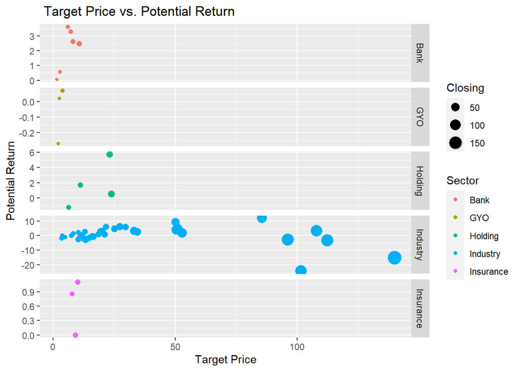

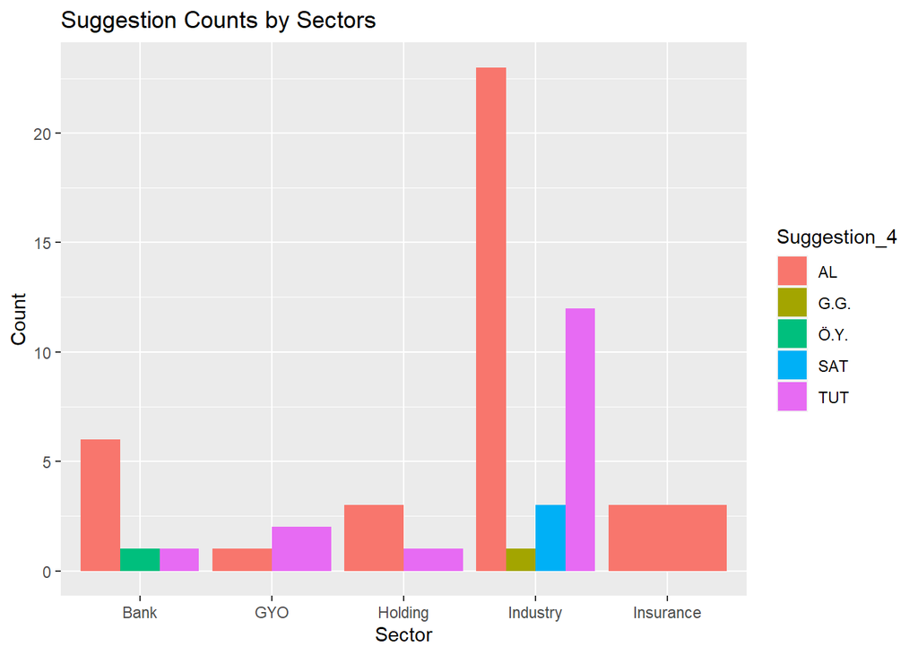

```r
summary_price_merged %>%
  select(Kod, Target_Price_4, Rev_Potential,Closing, Market_Price_mn, Sector) %>%
  filter(Kod!='OTKAR') %>%
  mutate(potential = Rev_Potential*Target_Price_4/100, Target_Price_4, Rev_Potential) %>%
  ggplot(aes(x=Target_Price_4, y=potential, size=Closing, color=Sector))+
  geom_point()+
  facet_grid(Sector ~., scales = "free")+
  labs(title =" Target Price vs. Potential Return", x = "Target Price", y = "Potential Return")


suggestion_sector <-
  summary_price_merged %>% select(Sector, Suggestion_4) %>%
  group_by(Sector, Suggestion_4)

ggplot(suggestion_sector, aes(x= Sector, fill=Suggestion_4))+
  geom_bar(position='dodge')+
  labs(title ="Suggestion Counts by Sectors", x = "Sector", y = "Count")
```

### Change in Target Prices

```r
change_price <-
  summary_price_merged %>% select(Kod, Target_Price, Target_Price_3, Target_Price_4) %>%
  mutate(change_1=(Target_Price_3/Target_Price-1)*100, change_2=(Target_Price_4/Target_Price_3-1)*100,
         tot_chane=(Target_Price_4/Target_Price-1)*100)

firstchangevalue <- change_price %>% summarise(avg_change=mean(change_1, na.rm = T))
totchangevalue <- change_price %>% summarise(avg_change=mean(tot_chane, na.rm = T))
```

Lastly I wanted to check what percentage of predictions on target prices had changed.

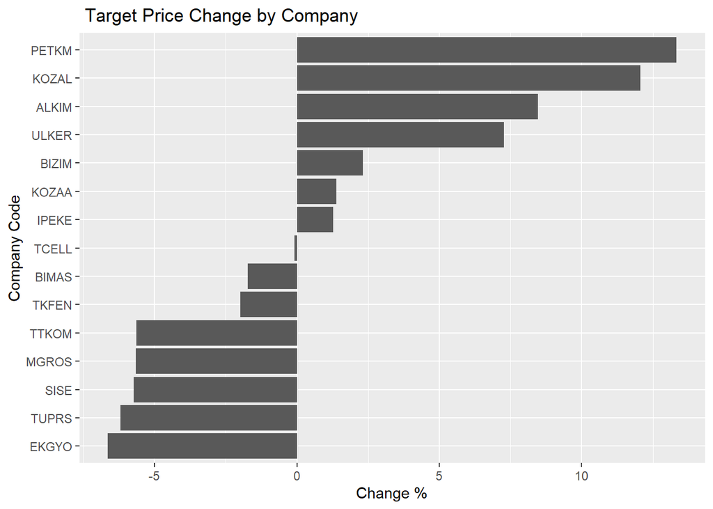

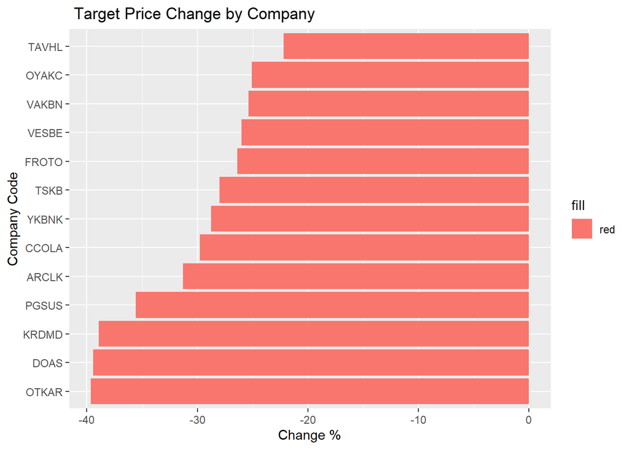

```r
change_price %>% arrange(desc(tot_chane)) %>% head(15) %>%
  ggplot(aes(x=reorder(Kod, tot_chane), y=tot_chane))+
  geom_bar(position = "stack", stat = "identity")+
  coord_flip()+
  labs(title =" Target Price Change by Company", x = "Company Code", y = "Change %")

change_price %>% arrange(desc(tot_chane)) %>% tail(15) %>% filter(is.na(tot_chane)!= TRUE) %>%
  ggplot(aes(x=reorder(Kod, tot_chane), y=tot_chane, fill='red'))+
  geom_bar(position = "stack", stat = "identity")+
  coord_flip()+
  labs(title =" Target Price Change by Company", x = "Company Code", y = "Change %")
```